# LDP internship - Data dictionary for original trawl biosample files

Alice Assmar

2026-02-04

**Agency Supervisors** Howard Stiff (Howard.Stiff@dfo-mpo.gc.ca), Athena Ogden (athena.ogden@dfo-mpo.gc.ca), Patrick Thompson (Patrick.Thompson@dfo-mpo.gc.ca)

**CIEE LDP supervisor** David Hunt (LDP Post-Doc, McGill University)

### 01_DAT folder

*.dat files from 1984 - 1999*

- These were the data as they were first entered into electronic form. Some of the original field data sheets are still available, but here we have used the *.dat files instead. Here we are showing an example from 1985:

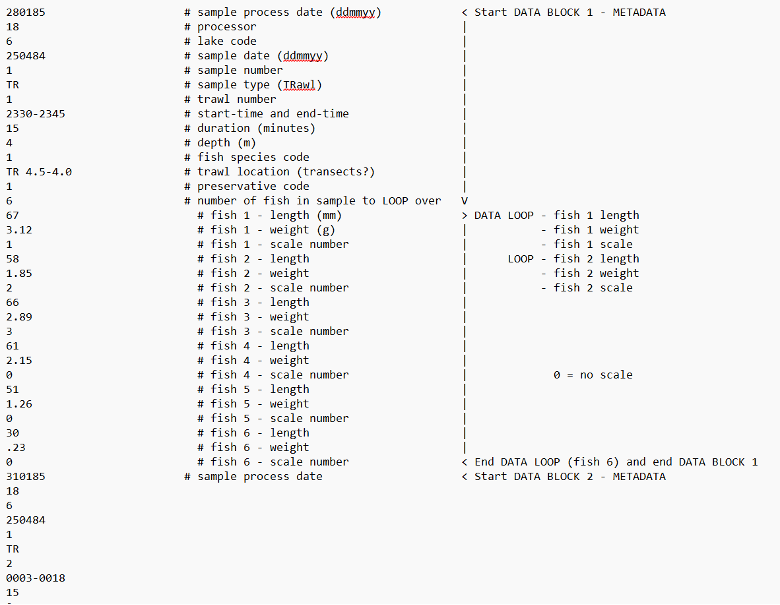

Figure. Sample screenshot of an Apple computer “DAT” file, with rows annotated for the first trawl survey in the file.

- Each table row (except the header) is one line.

- Apple DAT file field names and details:

[output not shown]

*.dat Files from 1977-1983*

- For 1977-1983, the only files available were saved in a tabular text format (also named as *.dat files) that differed from the original Apple *.dat file format. These files are the only representative datasets for the early years 1977-1983. Unfortunately, the tabular format did not fully preserve all the original data fields. These files are presumed to have been generated by SAS software, which may have over-written the original TrawlYY.DAT files with the limited tabular format, which resembled this:

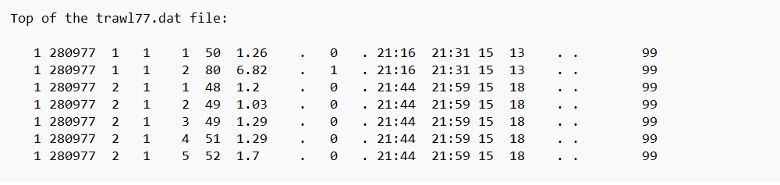

Figure. *.Dat files from 1977-1983.

- There are 17 columns in the SAS-originated Trawlyy.dat files:

column1: lake code  
column2: trawl date  
column3: trawl number  
column4: species code  
column5: Fish number  
column6: Length (mm)  
column7: Weight (g)  
column8: prsrv  
column9: age  
column10: aged  
column11: start time  
column12: end time  
column13: duration (min)  
column14: depth (m)  
column15: Number of fish  
column16: “procdate” (processing date)  
column17: processor (Observer code)

### 01_SAS_Data folder

- SAS versions of the data have the proprietary binary SAS dataset format, stored as *.sas7bdat files, e.g., Trawl87.sas7bdat.
- Trawlyy.sas7bdat files include fish data, while trlinfyy.sas7bdat files include trawl information, where yy is the ATS year.
  - Names of the variables present in the Trawlyy.sas7bdat files:
    - *date - Sample Date*
    - *age - Age*
    - *aged - Aging Technique*
    - *fishnmbr - Fish*
    - *system - System*
    - *length - Length (mm)*
    - *sample - Sample No.*
    - *fspecies - Species*
    - *stdwght -Standardized Weight (g)*
    - *trwlnmbr - Trawl*
    - *weight - Weight (g)*
    - *depth*
    - *observer - Processor* (From 1982 to 1999 only)
    - *Scale - Scale No.* (From 1982 to 1999 only)
    - *sclbook - Scale Book* (From 1982 to 1999 only)
  - Names of the variables present in the Trlinfyy.sas7bdat files:
    - *system - System*
    - *date - Sample Date*
    - *trwlnmbr - Trawl #*
    - *depth - Depth*
    - *fspecies - Species*
    - *statime - Start time*
    - *endtime - End time*
    - *prsrv - Preservative*
    - *observer - Observer*
    - *duration - Duration*
    - *nmbrfish - Number of fish*
    - *comment - Comments*

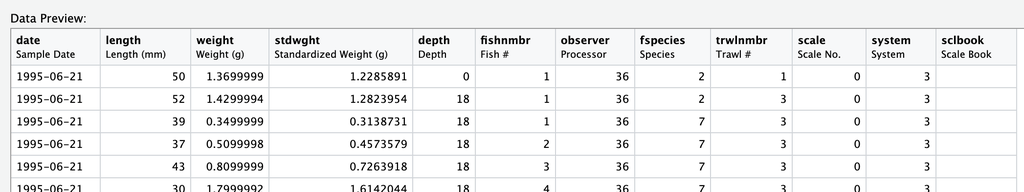

Sample screenshot of an Trawlyy.sas7bdat file.

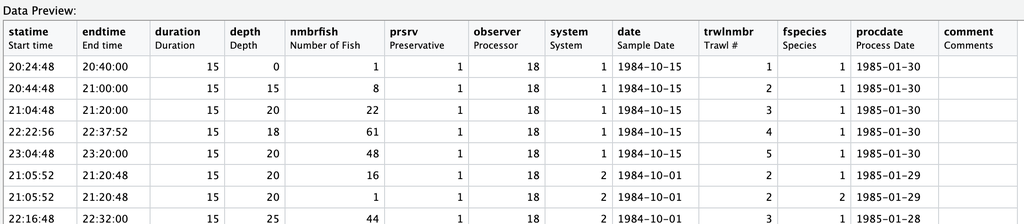

Sample screenshot of an Trlinfyy.sas7bdat file.

- Because some of the SAS files are corrupted (see below), and because the SAS datasets are synthetic and derived from the original Apple Computer *.dat files, the data in the *.dat from the Apple *.dat files were given preference when both were available:  
- Years: 1984, 1988, 1989, 1990, 1991, 1992, 1993, 1995, 1996.

- The following are corrupted SAS files, because their metadata have some structural problem:
  - trawl85.sas7bdat
  - trawl86.sas7bdat
  - trawl87.sas7bdat
  - trawl94.sas7bdat
  - trawl97.sas7bdat
  - trawl98.sas7bdat

### 03_AA_look_up_tables

Contains five .csv lookup and correction tables developed or modified during Alice Assmar’s internship. These tables include information on fish species common names, preservative code formulas, calculated standardized weights, and corrections applied to trawl times and fish length and weight measurements. These reference tables were created to standardize and validate the data by linking coded variables in the dataset to additional descriptive information not originally available in the source databases.

### 04_YS_look_up_tables

Contains five .csv lookup and correction tables developed or modified during Yuliya Shtymburski’s internship. These tables include information on lake names and locations, fish species codes, and preservative code formulas. These reference tables were created to standardize and validate the data by linking coded variables in the dataset to additional descriptive information not originally available in the source databases.